# Intactness and footprint maps

[Pierre Vernier](http://prv.updog.co)

01 November 2018

### Description and coverage of intactness maps from Canada and Alaska

Intactness datasets can help conservation planners to design and evaluate protected areas. This page describes existing global and regional datasets that measure intactness directly or indirectly i.e., human footprint maps. The geographic focus is on the boreal region of North America.

### North America

**Global Intact Forest Landscapes (Potapov et al. 2008, 2017).** The Global Intact Forest Landscapes maps (GIFL 2000, GIFL 2013, GIFL 2016) describe large unbroken expanses of natural ecosystems for the years 2000, 2013 and 2016 within areas of current forest extent, without signs of significant human activity, and having an area of at least 500 km2. The forest zone boundary was defined using a global tree canopy cover dataset (MODIS 500m) and included all areas with a tree canopy cover > 20% in the year 2000. The global IFL maps were created using maps of human settlements and transportation networks and a global coverage of high spatial resolution satellite imagery (Landsat 5 & 7, 30m).

- View and download data: http://www.intactforests.org/
- Distribution in Canada and Alaska:

Global IFL 2016

Global IFL 2013

Global IFL 2000

[figure not shown]

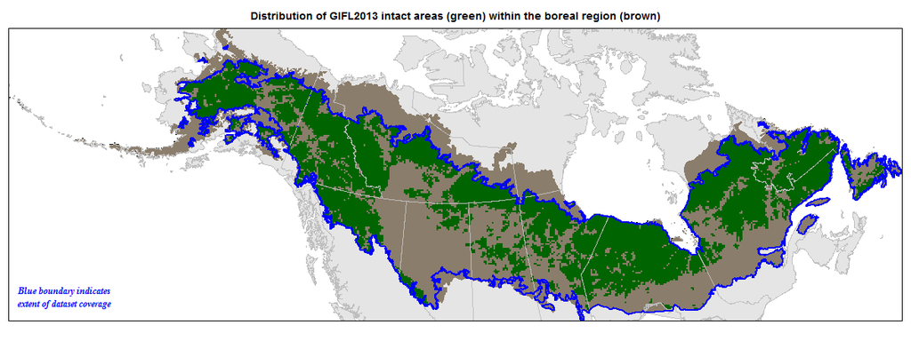

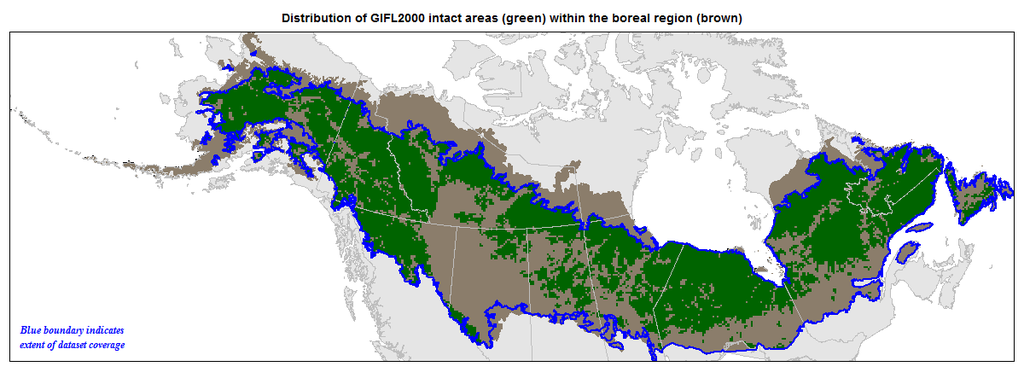

- References: Sanderson et al. 2002, Venter et al. 2016a, 2016b
- Download data (new versions): http://datadryad.org/resource/doi:10.5061/dryad.052q5
- Download data (older version): http://sedac.ciesin.columbia.edu/wildareas/
- Distribution in Canada and Alaska:

Human Footprint 2009

Human Footprint 1993

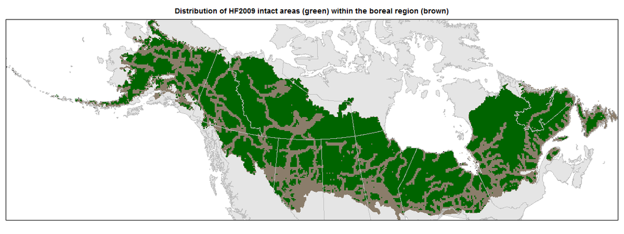

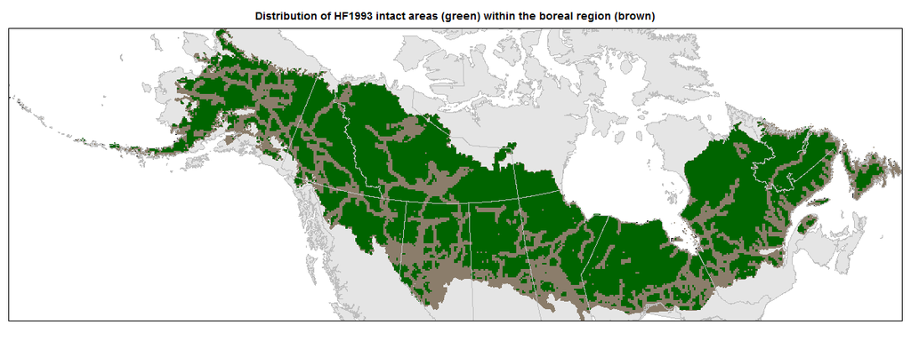

**Frontier Forests (Bryant et al. 1997).** The Forest Frontiers (FF) map was the first attempt to create a global map of the remaining large, ecologically intact, and relatively undisturbed natural forest landscapes. The map shows where the last remaining large areas of forest remains and provides an assessment of the degree of threat (low or no threat, medium or high threat, unassessed for threat). The maps were created from readily-accessible, but variable, ancillary information such as roads, and numerous experts provided advice and reviews. Unlike the other more recent approaches, Frontier Forests did not use consistent and more recent data sources such as satellite imagery. The Forest Frontiers map was published in 1997 by World Resources Institute.

- Website: http://www.wri.org/publication/last-frontier-forests (16-Mar-2017: link no longer works)
- Distribution in Canada and Alaska:

Frontier Forests

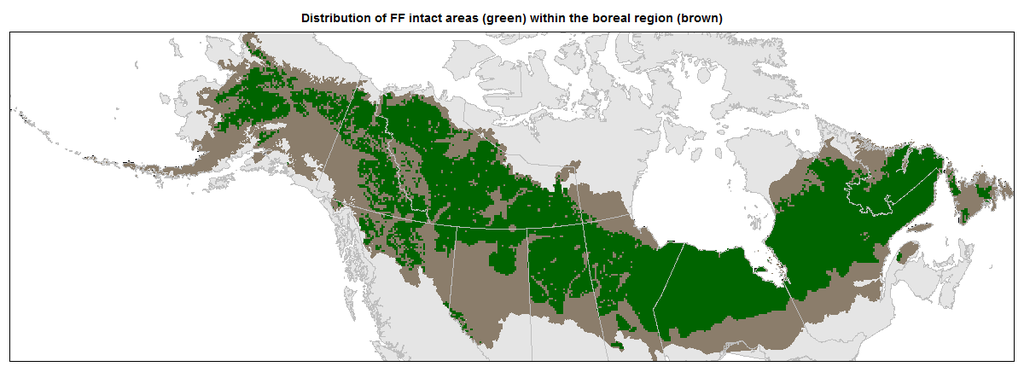

**HANPP (Haberl et al. 2007).** Human appropriation of net primary productivity (HANPP) represents the aggregate impact of land use on biomass available each year in ecosystems and is considered to be a prominent measure of human domination of the biosphere. HANPP is based on vegetation modeling, agricultural and forestry statistics, and geographical information systems data on land use, land cover, and soil degradation that localizes human impact on ecosystems. Global HANPP maps are available as PDF files while several underlying land use datasets are available in digital raster format including a map of wilderness and unproductive areas produced by the same authors (Erb et al 2007) which may be of most interest for selecting benchmarks. Other approaches have been used to calculate HANPP (e.g., Imhoff et al 2004) and these are reviewed in the main website.

- Download data (Wilderness and unproductive areas): http://www.uni-klu.ac.at/socec/inhalt/1189.htm
- Distribution in Canada and Alaska:

HANNP Unused

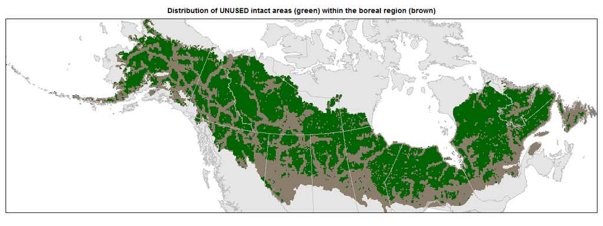

**Anthromes (Ellis and Ramankutty 2008).** From The Encyclopedia of Earth: “Anthropogenic biomes describe globally-significant ecological patterns within the terrestrial biosphere caused by sustained direct human interaction with ecosystems, including agriculture, urbanization, forestry and other land uses. Conventional biomes, such as tropical rainforests or grasslands, are based on global vegetation patterns related to climate. Now that humans have fundamentally altered global patterns of ecosystem form, process, and biodiversity, anthropogenic biomes provide a contemporary view of the terrestrial biosphere in its human-altered form. Anthropogenic biomes may also be termed”anthromes" to distinguish them from conventional biome systems, or “human biomes” (a simpler but less precise term)". The three wildland categories (wild forest, sparse trees, and barren) are of primary interest.

- Website: http://www.ecotope.org/anthromes/default.aspx
- Distribution in Canada and Alaska:

Anthromes Wild

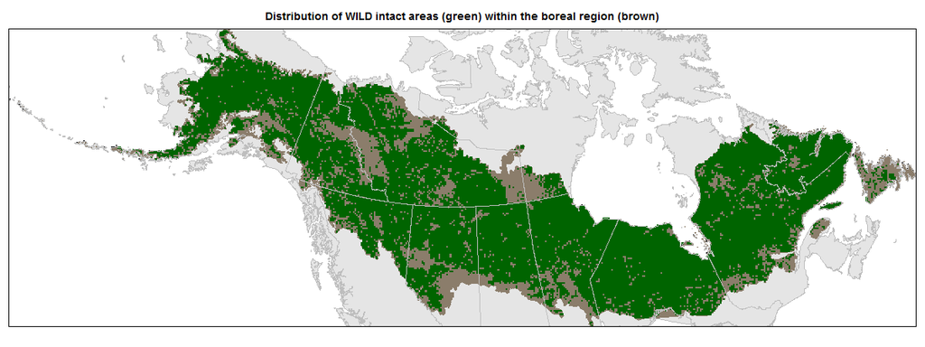

**GLOBIO (UNEP 2001).** GLOBIO is a modelling framework that can be used to calculate the combined effects of five broad environmental drivers on indicators of biodiversity in the past, present and future. The framework combines several established models used to assess the cumulative effects of human pressures on biodiversity worldwide. The GLOBIO models are based on scientific literature reviews to develop dose-response relationships between biodiversity indicators and various human pressures. The main biodiversity indicator map produced by GLOBIO is the Mean Species Abundance (MSA) and Ecosystem extent. MSA is an indicator of naturalness or biodiversity intactness. It is defined as the mean abundance of original species relative to their abundance in undisturbed ecosystems. An area with an MSA of 100% means a biodiversity that is similar to the natural situation. An MSA of 0% means a completely destructed ecosystem, with no original species remaining. The most recent version of the model, GLOBIO 3.0, evaluates the impacts of infrastructure development (e.g., roads, pipelines, powerlines, settlements), land use change and land use intensity, climate change and nitrogen deposition on biodiversity.

- Website: http://www.globio.info
- Distribution in Canada and Alaska:

GLOBIO MSA

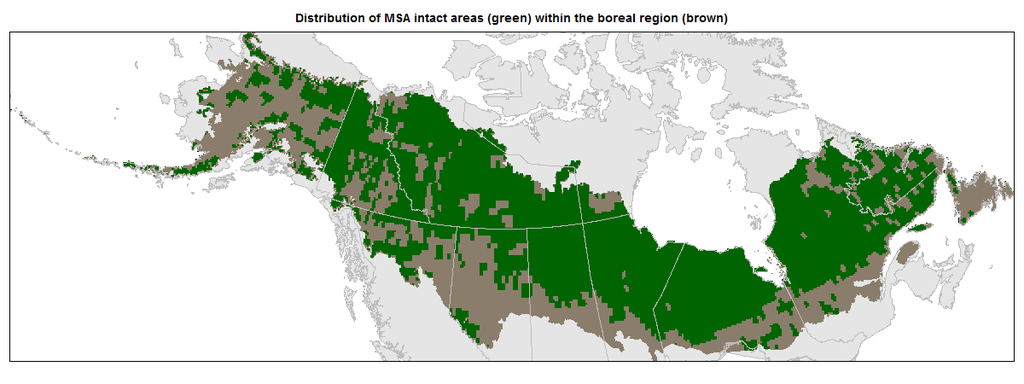

### Canada

**Canada Intact Forest Landscapes (Lee 2006, Smith and Cheng 2016).** The Intact Forest Landscapes maps (CIFL 2000 and CIFL 2013) depict Canada’s remaining forest landscape fragments for the years 2000 and 2013. The datasets use specified size thresholds of 5,000 hectares for boreal regions and 1,000 hectares for temperate forest regions. The map was produced using (i) existing datasets describing major anthropogenic changes/disturbances (e.g., roads, other linear features, reservoirs) to exclude large areas influenced by human activities and (ii) satellite imagery (Landsat 5 and 7, 30m) to identify finer scale anthropogenic disturbances (e.g., cutblocks, cutlines) within candidate intact forest landscapes.

- Download data: http://globalforestwatch.ca/node/252
- Distribution in Canada and Alaska:

Canada IFL 2013

Canada IFL 2000

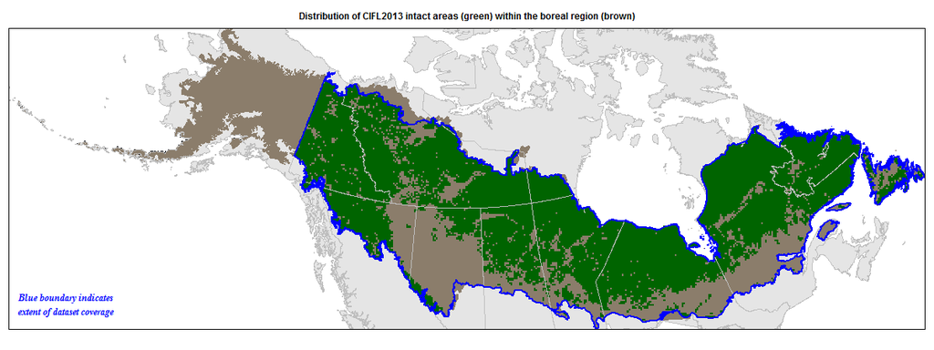

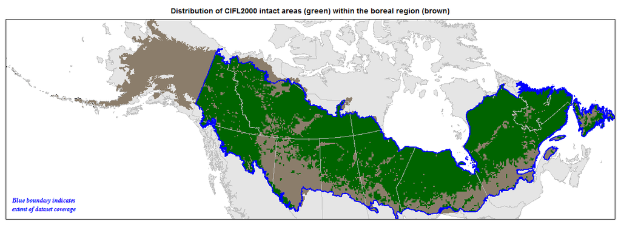

### Alaska

**Northwest Boreal LCC Anthropogenic Footprint (Geist et al. 2017).** The Northwest Boreal LCC Anthropogenic Footprint maps the human footprint (currently mining) across interior Alaska and northwestern Canada. The map provides a seamless dataset that spanned state, provincial and territorial boundaries to represent an initial look at intactness in the boreal ecosystems of western Canada and Alaska.

- Online map: https://accsmaps.maps.arcgis.com/apps/Styler/index.html?appid=23f6711c8955419589d31cd5da582839
- Website: http://accs.uaa.alaska.edu/landscape-ecology/northwest-boreal-anthropogenic-footprint/

**Alaska Landscape Intactness (Trammell and Aisu 2016).** The landscape condition model (LCM) was developed to measure the impact of the human footprint on a landscape. The LCM weighs the relative influence of different types of human activities to arrive at five condition classes ranging for very low (0.0-0.2) to very high (0.8-1.0) impact. The “very low” class combined with the Alaska IFL was then used to derive a landscape intactness dataset.

- Website: http://accs.uaa.alaska.edu/?s=Landscape+Integrity
- View report: http://accs.uaa.alaska.edu/files/rapid-ecoregional-assessments/cyr/CentralYukonREA_SectionF_LandscapeIntegrity.pdf

Landscape Intactness

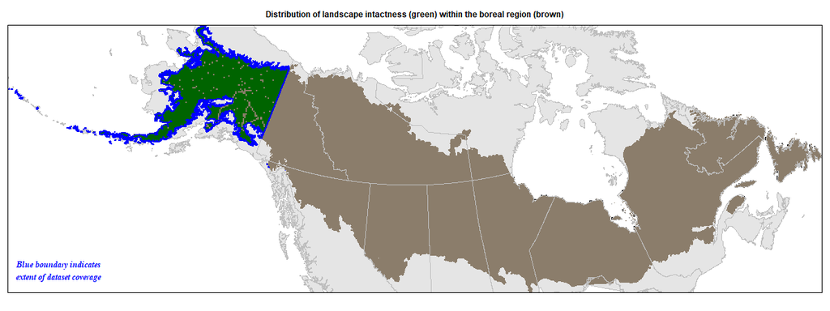

**Alaska Intact Forest Landscapes (Strittholt et al. 2006).** The Intact Forest Landscapes (IFL) map depicts Alaska’s remaining forest landscape fragments using three classes: 5,000-10,000 hectares, 10,000-50,000 hectares, and >50,000 ha. The map was produced using (i) existing datasets describing major anthropogenic changes/disturbances (e.g., roads, other linear features, reservoirs) to exclude large areas influenced by human activities and (ii) satellite imagery (Landsat 5 and 7, 30m) to identify finer scale anthropogenic disturbances (e.g., cutblocks, cutlines) within candidate intact forest landscapes. Note that, similar to the Canada IFL dataset, fires were treated as natural disturbances.

- Website: http://www.wri.org/publication/mapping-undisturbed-landscapes-alaska
- Download data: https://databasin.org/search/#query=Alaska%20intact%20forest%20landscapes

**Alberta Human Footprint (ABMI 2017).** From the ABMI website: “This comprehensive layer (updated every two years) includes human footprint information related to the energy, forestry, and agriculture industries, as well as urban development. The ABMI’s human footprint information is core to understanding relationships between human land use, habitat, and species abundance. These data are used to support policy development, regional planning, and cumulative effects management decisions.” The Human Footprint Index (HFI) has being developed for 2007, 2010, 2012, 2014.

- Website: http://www.abmi.ca/home/data-analytics/da-top/da-product-overview/GIS-Human-Footprint-Land-Cover-Data/HF-inventory.html

### References

Bryant, D., Nielsen, D., Tangley, L. 1997. The last frontier forests: Ecosystems and economies on the edge. World Resources Institute, Washington, D.C.

Ellis, E.C., and Ramankutty, N., 2008. Putting people in the map: anthropogenic biomes of the world. Frontiers in Ecology and the Environment 6, doi:10.1890/070062. URL: http://www.esajournals.org/doi/abs/10.1890/070062

Erb, K.-H., Gaube, V., Krausmann, F., Plutzar, C., Bondeau, A., Haberl, H. 2007. A comprehensive global 5min resolution land-use dataset for the year 2000 consistent with national census data. Journal of Land Use Science 2(3): 191-224. URL: http://www.informaworld.com/smpp/content~content=a783007657~db=all~order=page

Geist, M., M. Aisu , P. Lema & E. J. Trammell. 2017. Spatial estimates of surface mining footprints in northwest boreal ecoregions of Alaska and Canada.

Haberl, H., Erb, K.H., Krausmann, F., Gaube, V. Bondeau, A., Plutzar, C., Gingrich, S., Lucht, W., Fischer-Kowalski, M. 2007. Quantifying and mapping the human appropriation of net primary production in earth’s ecosystems. PNAS (104): 12942-12947. URL: http://www.pnas.org/content/104/31/12942.full

Imhoff, M. L., Bounoua, L., Ricketts, T., Loucks, C., Harriss, R., Lawrence, W. T. 2004. Global patterns in human consumption of net primary production. Nature 429, 870-873. URL: http://sedac.ciesin.columbia.edu/es/hanpp.html

Lee, P., Gysbers, J.D., Stonojevic, Z. 2006. Canada’s forest landscape fragments: A first approximation (A Global Forest Watch Canada Report). Edmonton, Alberta: Global Forest Watch Canada. 97pp.

Lee, P. G. 2009. Caution against using intact forest-landscapes data at regional scales. Ecology and Society 14(1): r1. URL: http://www.ecologyandsociety.org/vol14/iss1/resp1/

Potapov, P., Yaroshenko, A., Turubanova, S., Dubinin, M., Laestadius, L., Thies, C., Aksenov, D., Egorov, E., Yesipova, Y., Glushkov, I., Karpachevskiy, M., Kostikova, A., Manisha, A., Tsybikova, E., Zhuravleva, I.. 2008. Mapping the world’s intact forest landscapes by remote sensing. Ecology and Society 13(2): 51. URL: http://www.ecologyandsociety.org/vol13/iss2/art51/

Potapov, P., Hansen, M.C., Laestadius, L., Turubanova, S., Yaroshenko, A., Thies, C., Smith, W., Zhuravleva, I., Komarova, A., Minnemeyer, S., Esipova, E. 2017 The last frontiers of wilderness: Tracking loss of intact forest landscapes from 2000 to 2013. Science Advances 3: 1-13.

Sanderson, E.W., Jaiteh, M., Levy, M.A., Redford, K.H., Wannebo, A.V., Woolmer, G. 2002. The human footprint and the last of the wild. BioScience 52:891-904.

Smith, W. and Cheng, R. 2016. Canada’s Intact Forest Landscapes Updated to 2013. Ottawa: Global Forest Watch Canada. 26 pp.

Strittholt, J.R., Nogueron, R., Alvarez, M., and Bergquist, J. 2006. Mapping undisturbed landscapes in Alaska: An overview report. Conservation Biology Institute and World Resource Institute. URL: http://www.globalforestwatch.org/english/about/publications.htm (accessed February 2010).

UNEP. 2001. Nelleman, C., Kullerud, L., Vistnes, I., Forbes, B.C., Husby, E., Kofinas, G.P., Kaltenborn, B.P., Rouaud, J., Magomedova, M., Bobiwash, R., Lambrechts, C., Schei, P.J., Tveitdal, S., Gron, O., Larsen, T.S. GLOBIO. Global methodology for mapping human impacts on the biosphere. UNEP/DEWA/TR.01-3.

Venter, O. et al. 2016a Global terrestrial Human Footprint maps for 1993 and 2009. Sci. Data 3, 160067.

Venter, O. et al. 2016b. Sixteen years of change in the global terrestrial human footprint and implications for biodiversity conservation. Nat. Commun. 7, 12558